# Praca Domowa 1

Bartosz Topolski

3 marca 2016

# 1. Pobranie danych

Na początek musimy pobrać tweety do analizy. Postanowiłem zrobić proste wyszukiwanie, dając tylko hasło “oscars”. Tweety dotyczące Oscarów były oznaczane hasztagiem #Oscars, więc na dobry początek wystarczy. Kolejne wyszukiwania będę przeprowadzał już na pobranych tweetach.  
Tweety pobrałem w oddzielnym skrypcie, w liczbie 15000, a następnie zapisałem do pliku, aby potem móc na nich pracować. Tak mała ilość danych wynika niestety z tego, że po pobraniu pewniej ilości tweetów dostawałem informację o tym, że przekroczyłem dozwoloną ilość pobrań. Niestety nie udało mi się obejść tego problemu.

```r
tweets <- searchTwitter("oscars", n=15000, since = "2016-02-28", until = "2016-03-01")
saveRDS(tweets, file = file.path(getwd(), "RandBigData", "tweety.Rdata"))
```

# 2. Ogólne statystyki

Aby wygodniej pracowało się na pobranych danych, konwertujemy je do `data.frame`.

```r
tweets_df <- twitteR::twListToDF(tweets)
```

Możemy teraz wyznaczyć różne interesujące nas, mniej lub bardziej, informacje.  
Poniższy kod pokazuje tweety najczęsciej dodawane do ulubionych, oraz najczęściej retweetowane. Mamy też listę 10 użytkowników, którzy najczęściej tweetowali (oczywiście bierzemy pod uwagę fakt, że zbiór danych jest niepełny).

```r
tweets[[which.max(tweets_df$favoriteCount)]]
```

```
## [1] "chrisrock: #RockBiden2020 #oscars https://t.co/3mk6EwGVyX"
```

```r
tweets[[which.max(tweets_df$retweetCount)]]
```

```
## [1] "zainft6god: RT @TheEllenShow: If only Bradley's arm was longer. Best photo ever. #oscars http://t.co/C9U5NOtGap"
```

```r
top_tweeters <- tweets_df %>% count(screenName) %>% arrange(desc(n)) %>% top_n(10)
top_tweeters
```

```
## Source: local data frame [12 x 2]
##
##         screenName     n
##              (chr) (int)
## 1       1203prince    81
## 2     tonkinbright    35
## 3       AnnaZhang0    23
## 4     heygirlbella    23
## 5          prfctzm    22
## 6      andreavdiaz    20
## 7  black_dreamer13    20
## 8      loraclarryy    20
## 9   michonnrgrimes    20
## 10    kingsmancash    18
## 11      wishesizzy    18
## 12   ZuriAnderson1    18
```

# 3. Podzapytania i analiza sentymentu

Wyszukamy teraz informacje o interesujących nas aktorach i filmach.

```r
dicaprio <- lapply(tweets, function(x) !is.na(stri_extract_all_fixed(stri_trans_tolower(x$text),"dicaprio")))
spotlight <- lapply(tweets, function(x) !is.na(stri_extract_all_fixed(stri_trans_tolower(x$text),"spotlight")))
madmax <- lapply(tweets, function(x) !is.na(stri_extract_all_fixed(stri_trans_tolower(x$text),"max")))
tweets_dicaprio <- tweets[unlist(dicaprio)]
tweets_spotlight <- tweets[unlist(spotlight)]
tweets_madmax <- tweets[unlist(madmax)]
```

Filmy i aktor zostali wybrani po to, żeby sprawdzić jak użytkownicy Twittera reagowali na ich sukcesy/porażki. Pomysł na taką a nie inną realizację zabawy z danymi w ramach pracy domowej powstał w oparciu o prezentację z wyjazdu integracyjnego SMADu.  
Porównując ilości wyszukanych tweetów widzimy, że najczęściej ludzie pisali o Leonardo DiCaprio.

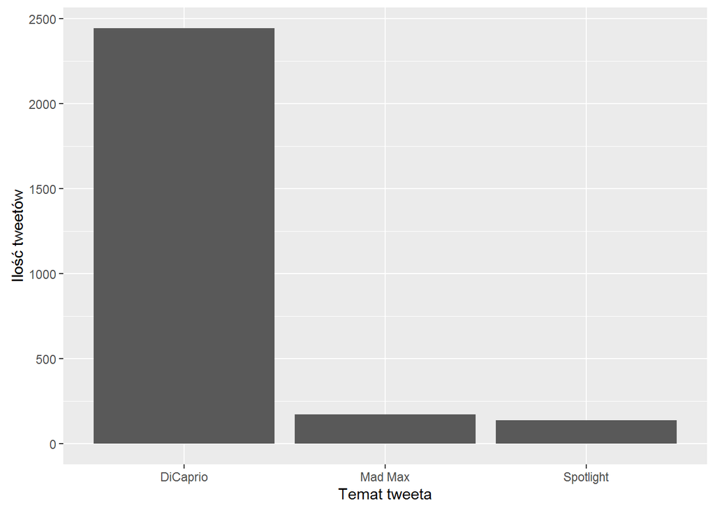

```r
licznosci <- c(length(tweets_dicaprio),length(tweets_spotlight),length(tweets_madmax))
ggplot(data.frame(licznosci),aes(c("DiCaprio", "Spotlight", "Mad Max"),licznosci))+geom_bar(stat="identity")+
  ylab("Ilość tweetów") + xlab("Temat tweeta")
```

Aby móc ocenić wydźwięk tweeta, potrzebujemy słownika, który będzie nadawał słowom wartośc liczbową oceniającą ich wydźwięk. Skorzystałem ze słownika VADER Sentiment Analysis ( “https://github.com/cjhutto/vaderSentiment”). Zawiera on około 7,500 słów, skrótów i emotikonów, oraz przypisaną im wartość sentymentu. Dwóch ostatnich się jednak pozbyłem, aby ułatwić czytanie słownika. Wciąż, do dyspozycji mamy ponad 7000 słów.  
Po wczytaniu słownika, stworzyłem także funkcję nadająca danemu stringowi jego ocenę, w sposób najbardziej prymitywny: poprzez sumę wartości przypisanych każdemu słowu.

```r
slownik_raw <- read.table(file.path(getwd(),"vader_sentiment_lexicon.txt" ),sep = "\t", quote = "\"")
slownik <- data.frame(slownik_raw, row.names = 1)
ranguj <- function(x) {
  slowa <- unlist(stri_extract_all_words(x))
  wynik <- sum(slownik[slowa,1], na.rm = T)
  wynik
}
```

Możemy teraz porangować tweety z poszczególnych wyszukiwań.

```r
sent_spotlight <-sapply(tweets_spotlight, function(x) ranguj(x$text))
sent_dicaprio <- sapply(tweets_dicaprio, function(x) ranguj(x$text))
sent_madmax <- sapply(tweets_madmax, function(x) ranguj(x$text))
sent_ogolnie <- sapply(tweets, function(x) ranguj(x$text))
```

# 4. Wyniki analizy

## 4.1 Leonardo DiCaprio

Dla internautów zdobycie przez DiCaprio Oscara było dużym powodem do radości - od dłuższego czasu wszyscy mu w tym kibicowali. Widzimy, że większość tweetów o nim miała wydźwięk pozytywny.

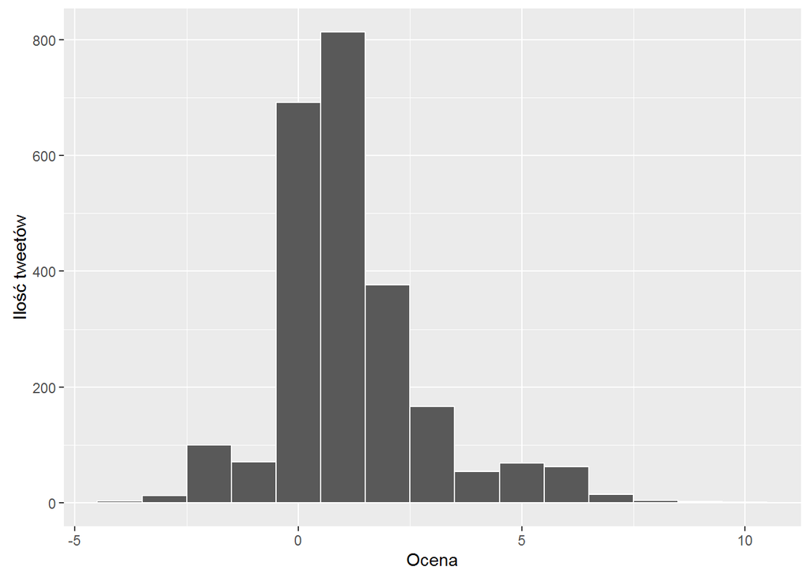

```r
qplot(sent_dicaprio, geom = "histogram",
      binwidth = 1, col = I("white") ) + ylab("Ilość tweetów") + xlab("Ocena")
```

Posortowanie tweetów według ich oceny przez nasz algorytm pozwala na znalezienie kilku ciekawych wpisów:

```r
tweets_dicaprio[397]
```

```
## [[1]]
## [1] "YoutubeBri: RT @SmartInsults: I no longer have the same number of Oscars as Leonardo DiCaprio and that makes me sad"
```

```r
tweets_dicaprio[2296]
```

```
## [[1]]
## [1] "NathanNmred4: All these plastic fans slushing over Leonardo for his Oscar. Just a shame it's a crap film! #LeonardoDiCaprio #Oscars #Revenant"
```

Niestety jednak, dość dobrze widać że taki sposób oceny tweetów nie jest zbyt dobry. Oto najgorzej oceniony przez algorytm tweet. Nie ma on jednak negatywnego wydźwięku, a wręcz przeciwnie.

```r
tweets_dicaprio[order(sent_dicaprio)[1]]
```

```
## [[1]]
## [1] "ragingzxyn: RT @LilTunechi: Dam i hav to hit the stage &amp; kant watch the Oscars. But rootin for my brother, Leonardo DiCaprio to take it home."
```

## 4.2 Spotlight

Spotlight dostał w tym roku Oscara jako najlepszy film. Tutaj widzimy że dużo tweetów miało wydźwięk neutralny, ale sporo też było opinii pozytywnych:

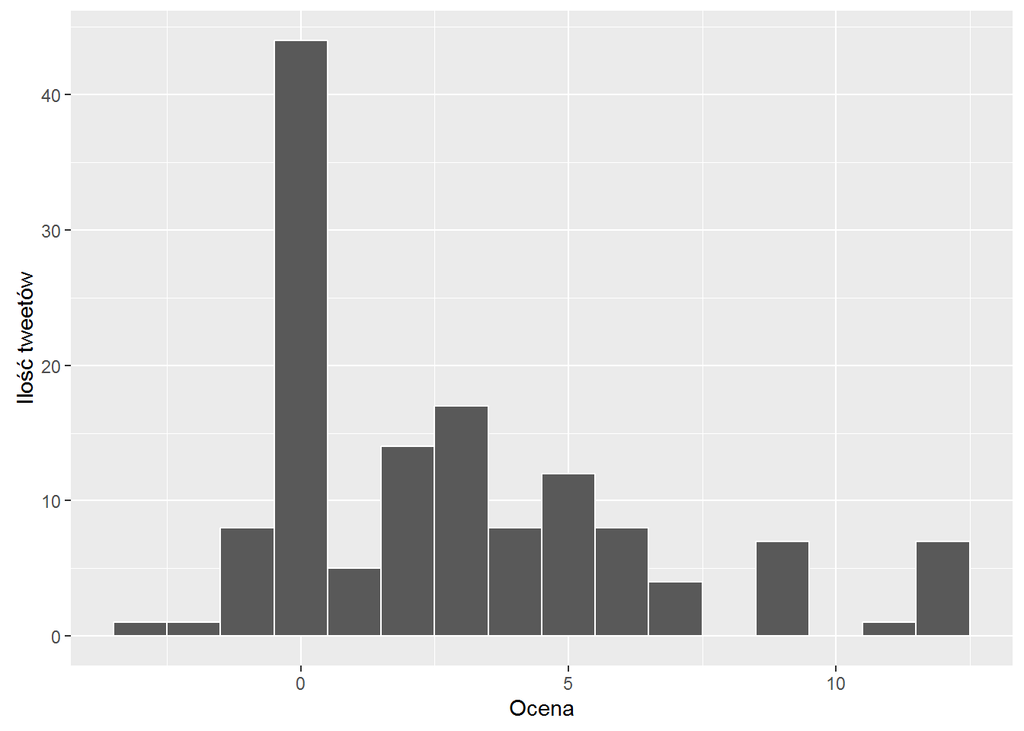

```r
qplot(sent_spotlight, geom = "histogram",
      binwidth = 1, col = I("white") )+ ylab("Ilość tweetów") + xlab("Ocena")
```

Przeglądając posortowane tweety, możemy znaleźć opinie zarówno negatywne, jak i skrajnie pozytywne:

```r
tweets_spotlight[9]
```

```
## [[1]]
## [1] "shirIeymaclaine: RT @gonegirlscat: Spotlight winning BP after mad max won 6 oscars make zero sense to me, its like what happened with the grand budapest hot…"
```

```r
tweets_spotlight[17]
```

```
## [[1]]
## [1] "BunnyRabbitHops: RT @ClimateReality: A big congratulations on the Oscar for #Spotlight, @MarkRuffalo. Thank you for all you do to #ActOnClimate! #Oscars htt…"
```

```r
tweets_spotlight[47]
```

```
## [[1]]
## [1] "TheBurningBooks: Watched Spotlight. Competent but not compelling. They give Oscars to TV movies now?"
```

Ciekawostką jest to, że pierwszy z tych tweetów został zaklasyfikowany w top 20 pozytywnych wpisów.

## 4.3 Mad Max

Film, który w tym roku dostał największą ilość Oscarów (aż 6) to Mad Max: Fury Road. Podobnie jak wcześniej, największa ilość tweetów miała wydźwięk neutralny, było też również spora ilość pozytywnych:

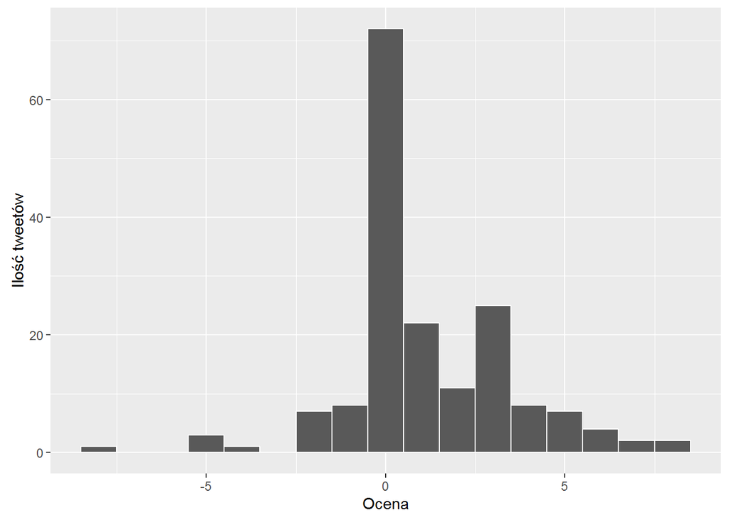

```r
qplot(sent_madmax, geom = "histogram",
      binwidth = 1, col = I("white") )+ ylab("Ilość tweetów") + xlab("Ocena")
```

Wśród tweetów o tym filmie znalazłem chyba najbardziej negatywny spośród wszystkich wyrzuconych przez algorytm:

```r
tweets_madmax[63]
```

```
## [[1]]
## [1] "ADOEG: Mad max?? 6 Oscars? ?? The fak.. that movie sucked like a baby calf suckling jew jew"
```

Innym ciekawym przypadkiem jest tweet wyrażający się dobrze o filmie, ale o negatywnym wydźwięku (zawód). W tym przypadku został on zaklasyfikowany jak najbardziej poprawnie.

```r
tweets_madmax[127]
```

```
## [[1]]
## [1] "PaulHaydon: The biggest Oscars disappointment for me is the fact that Mad Max: Fury Road didn't take out the Best Picture Oscar..."
```

## 4.4 Bonus

Patrząc na najbardziej negatywne tweety spośród wszystkich ściągniętych, widać że najczęściej przejawia się jeden temat:

```r
tweets[c(10050, 1281, 12754)]
```

```
## [[1]]
## [1] "maia_rikerr5: RT @ericgeller: \"Is Hollywood racist? You're damn right Hollywood's racist. ... Hollywood is sorority racist.\" KILLING IT.  #Oscars"
##
## [[2]]
## [1] "SmokinSam420: RT @WalshFreedom: The Oscars, for those who didn't watch: \n\n\"Diversity, diversity, diversity, diversity, racism, racism, diversity, racism,…"
##
## [[3]]
## [1] "fireflyWest: RT @swanlee99: Then #ChrisRock turned ignorant &amp; obnoxious. #asianschrisrock #AsiansRminority2 #AsiAms #asianoscars #Asians #racism\nhttps:/…"
```